# CCS d1 与 Direct-GSClassifier 消融实验

Bensz Conan

2026-08-06

本报告围绕一个明确问题展开：冻结 cohort bank 将同一份 529 维 GSClassifier 原生输入转换为 d1 后，旧癌种标签的可恢复性、技术来源聚集和输入信息可恢复性发生了什么变化。`cancer_type` 用于外部核查，不是 CCS 必须优化的目标。分析限于 d1；d2、d3、metaCCS、normCCS 和 ICI response 不用于反向证明 d1，癌种可恢复性也不替代对新状态效用的直接评价。

**核心结论：本次结果不支持 d1 更适合恢复旧癌种标签，也不足以否定 CCS 的新分型目标。** 在 k = 30 时，癌种一致率由 Direct 的 0.437 降至 d1 的 0.358，线性 readout balanced accuracy 从 0.367 降至 0.230，全训练学习曲线差为 -0.137。d1 **去强化了癌种主导的几何结构**，三个技术因子的邻居 excess 也均有下降，符合 feature 经多 cohort 模型重表达的设计方向。由于实验尚未测量新状态的稳定性、跨癌种生物意义或临床任务效用，这些结果只能为理解 CCS 核心假设提供机制线索，不能据此断言“过度混合已被证实”。

## 1 数据概览

### 1.1 原始数据与组织标签恢复

表达 RDS 共含 39112 个样本、193 个 cohort；旧结构只有 10 个顶层 tissue，其中 `Undefined` 汇集了 45 个已知 cohort 和 8626 个样本。这里不依据 cohort 名称猜测 tissue，而是逐行读取 `test/pre-train-info/scripts/tissue_mapping.csv` 的已核验映射，将这些 cohort 移入真实 tissue。重组后得到 32 个 tissue，未解析样本数为 **0**，样本数与 cohort 数均保持不变。

冻结 CCS bank 仍以历史 `Undefined/cohort` 作为部分 module provenance；报告因此同时保留 `bank_tissue/bank_cohort_key` 与真实 `tissue/cohort_key`。前者保证模型文件和审计哈希可追溯，后者用于数据分层、样本抽样和生物学解释。该双键设计避免了把“历史存储标签”误当成“未知组织”，也避免真实 tissue 恢复后丢失 43 个 external filtered cohort。

```r
# Purpose: Show every historical Undefined cohort and its audited tissue destination.
# Input: Full tissue-resolution audit from ablation-test-data.R.
# Parameters: Ten rows per page; no cohort is filtered from the interactive table.
# Output: Traceable mapping with sample/feature counts and analysis role.
render_dt(
  data_profile$resolution_audit[, c(
    "cohort", "source_tissue", "resolved_tissue", "sample_count",
    "feature_count", "analysis_set"
  )],
  pageLength = 10
)
```

|  | cohort | source_tissue | resolved_tissue | sample_count | feature_count | analysis_set |
| --- | --- | --- | --- | --- | --- | --- |
| 1 | MSK-BLCA-2013 | Undefined | BLCA | 58 | 32 | reference_atlas |
| 2 | Cornell-NatCom-2019 | Undefined | BLCA | 32 | 32 | reference_atlas |
| 3 | TCGATARGET-BLCA | Undefined | BLCA | 407 | 32 | external_query |
| 4 | TCGATARGET-CESC | Undefined | CESC | 306 | 32 | external_query |
| 5 | MET500-PanCan-2018_CHOL | Undefined | CHOL | 45 | 32 | reference_atlas |
| 6 | TCGATARGET-CHOL | Undefined | CHOL | 36 | 32 | external_query |
| 7 | CPTAC-GBM-2021 | Undefined | GBM | 99 | 32 | external_query |
| 8 | TCGATARGET-GBM | Undefined | GBM | 166 | 32 | external_query |
| 9 | MET500-PanCan-2018_HNSC | Undefined | HNSC | 45 | 32 | reference_atlas |
| 10 | TCGATARGET-HNSC | Undefined | HNSC | 520 | 32 | external_query |

[output cut: 35 more lines]

恢复规模最大的三个 tissue 是 LUAD = 996; LGG = 982; MISC = 640 个样本。该表保留所有 45 条映射及其 feature 数，因而审核者可以从任一真实 tissue 反查原始 `Undefined` cohort。后续若 `pre-train-info` 映射变化，数据契约会要求源 `Undefined` cohort 集合与映射表严格相等；不一致时主脚本直接停止，而不会静默丢弃或猜测标签。

### 1.2 样本与 reference-query 构成

```r
# ==== Data Figure 1: Tissue composition (user-adjustable parameters) ====
fig_data1 <- list(
  # A tall canvas keeps all resolved tissue labels legible; 8-12 in is suitable here.
  width_in = 7.4,
  height_in = 8.8,
  # Base font in pt. Values below 8 are avoided for print readability.
  base_size = 9,
  # Bar width controls separation between tissue rows; 0.65-0.85 is typical.
  bar_width = 0.76,
  # The bottom legend remains outside the data panel.
  legend_position = "bottom"
)

p_data1 <- ggplot2::ggplot(
  tissue_profile_plot,
  ggplot2::aes(
    x = .data$sample_count,
    y = .data$tissue,
    fill = .data$analysis_set
  )
) +
  ggplot2::geom_col(width = fig_data1$bar_width) +
  ggplot2::scale_fill_manual(values = c(
    "Reference atlas" = nature_colors[["blue"]],
    "External query" = nature_colors[["orange"]]
  )) +
  ggplot2::scale_x_continuous(
    labels = scales::label_number(big.mark = ",")
  ) +
  ggplot2::labs(
    x = "Samples",
    y = "Resolved tissue",
    fill = "Analysis set"
  ) +
  theme_nature_readable(
    base_size = fig_data1$base_size,
    x_text_angle = 0,
    legend_position = fig_data1$legend_position
  )

# Readability check: horizontal bars protect 32 tissue labels from overlap; the
# tall canvas and external legend keep both small and large strata visible.
fig_data1_jpg <- .ae_save_plot(
  p_data1, "figure-data-01-tissue-composition", figure_dir,
  preview_dir, fig_data1, params$plot_preview_dpi
)
```

```
## Converting page 1 to E:/RCloud/RFactory/ccs/test/ablation-02/tmp/plot-previews/ablation-experiment-20260806203223/figure-data-01-tissue-composition.jpg... done!
```

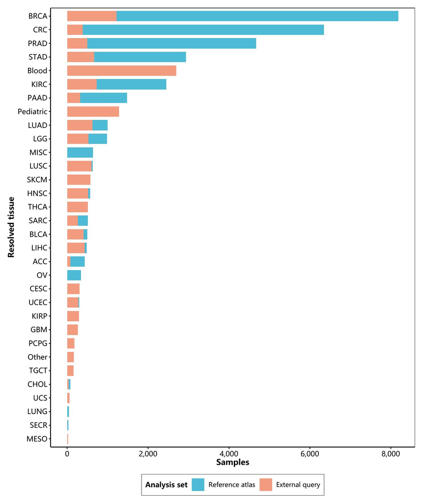

```r
knitr::include_graphics(fig_data1_jpg)
```

当前数据的构成结果显示，BRCA 是样本量最大的 tissue（8189 个样本、22 个 cohort），其次为 CRC（6346）和 PRAD（4671）。图中 reference/query 并非随机切分：external query 由冻结模型记录的 filtered cohort 决定，完整原始层面为 14083 个样本；实际表示实验随后排除跨 cohort 重复 sample ID，并要求 cancer_type 在 reference 中至少覆盖 2 个 cohort，因此确认性 query 收敛到 10103 个样本和 36 个 cohort。**这一构成差异提示，原始可用数据与满足外部验证合同的数据必须分开报告。**

### 1.3 cohort 规模与来源异质性

```r
# ==== Data Figure 2: Cohort scale heterogeneity (user-adjustable parameters) ====
fig_data2 <- list(
  width_in = 7.2,
  height_in = 5.2,
  base_size = 10,
  point_size_min = 2.4,
  point_size_max = 7.5,
  point_alpha = 0.82,
  label_size = 3.0,
  legend_position = "right"
)

p_data2 <- ggplot2::ggplot(
  tissue_totals,
  ggplot2::aes(
    x = .data$cohort_count,
    y = .data$sample_count,
    size = .data$median_cohort_size,
    color = .data$query_fraction
  )
) +
  ggplot2::geom_point(alpha = fig_data2$point_alpha) +
  ggplot2::geom_text(
    data = tissue_label,
    ggplot2::aes(label = .data$tissue),
    size = fig_data2$label_size,
    nudge_y = 0.10,
    check_overlap = TRUE,
    show.legend = FALSE
  ) +
  ggplot2::scale_y_log10(
    labels = scales::label_number(big.mark = ",")
  ) +
  ggplot2::scale_size_continuous(
    range = c(fig_data2$point_size_min, fig_data2$point_size_max)
  ) +
  ggplot2::scale_color_gradient(
    low = "grey75",
    high = nature_colors[["red"]],
    labels = scales::label_percent(accuracy = 1)
  ) +
  ggplot2::labs(
    x = "Cohorts per tissue",
    y = "Samples per tissue (log scale)",
    size = "Median cohort size",
    color = "External-query share"
  ) +
  theme_nature_readable(
    base_size = fig_data2$base_size,
    x_text_angle = 0,
    legend_position = fig_data2$legend_position
  )

# Readability check: the log scale preserves rare tissues without flattening large
# tissues; only the top sample-count tissues are labeled, preventing text collisions.
fig_data2_jpg <- .ae_save_plot(
  p_data2, "figure-data-02-cohort-scale", figure_dir,
  preview_dir, fig_data2, params$plot_preview_dpi
)
```

```
## Converting page 1 to E:/RCloud/RFactory/ccs/test/ablation-02/tmp/plot-previews/ablation-experiment-20260806203223/figure-data-02-cohort-scale.jpg... done!
```

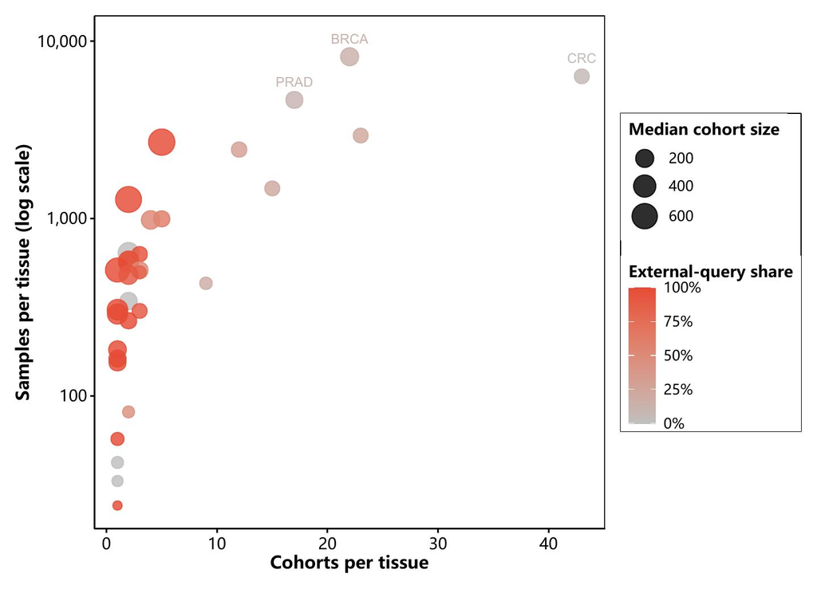

```r
knitr::include_graphics(fig_data2_jpg)
```

当前数据结果显示，各 tissue 存在跨量级的 cohort 与样本规模差异；最大单一 cohort 为 BRCA / METABRIC-BRCA-2012，含 1980 个样本。点大小进一步显示 median cohort size，颜色表示 external-query 占比，因此样本多不等于外部证据更充分。对样本量小或 query 占比较高的 tissue，后续 lineage-specific 结论应优先报告 cohort-level bootstrap 或 leave-one-cohort-out 区间；判据应是方向在独立 cohort 中保持一致，而不是由一个大 cohort 的样本数驱动总体均值。

```r
# ==== Data Figure 3: Source-system composition (user-adjustable parameters) ====
fig_data3 <- list(
  width_in = 6.8,
  height_in = 8.8,
  base_size = 9,
  tile_border_width = 0.35,
  legend_position = "right"
)

p_data3 <- ggplot2::ggplot(
  source_profile_plot,
  ggplot2::aes(
    x = .data$source_system,
    y = .data$tissue,
    fill = .data$tissue_fraction
  )
) +
  ggplot2::geom_tile(
    color = "white",
    linewidth = fig_data3$tile_border_width
  ) +
  ggplot2::scale_fill_gradient(
    low = "grey96",
    high = nature_colors[["purple"]],
    labels = scales::label_percent(accuracy = 1),
    limits = c(0, 1)
  ) +
  ggplot2::labs(
    x = "Source system",
    y = "Resolved tissue",
    fill = "Within-tissue share"
  ) +
  theme_nature_readable(
    base_size = fig_data3$base_size,
    x_text_angle = 30,
    legend_position = fig_data3$legend_position
  )

# Readability check: only three source columns are shown; a tall canvas preserves
# tissue labels, white tile borders separate cells, and the legend stays external.
fig_data3_jpg <- .ae_save_plot(
  p_data3, "figure-data-03-source-composition", figure_dir,
  preview_dir, fig_data3, params$plot_preview_dpi
)
```

```
## Converting page 1 to E:/RCloud/RFactory/ccs/test/ablation-02/tmp/plot-previews/ablation-experiment-20260806203223/figure-data-03-source-composition.jpg... done!
```

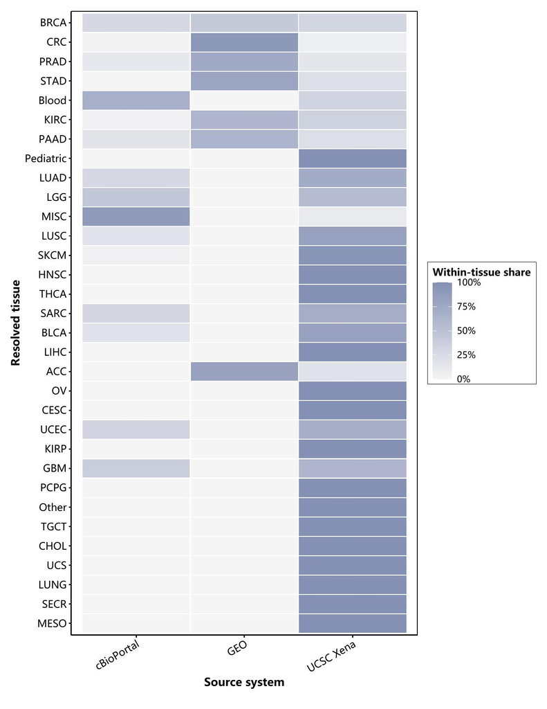

```r
knitr::include_graphics(fig_data3_jpg)
```

当前数据的来源构成结果显示，各 tissue 分别由 GEO、cBioPortal 或 UCSC Xena 以不同比例支撑；颜色按 tissue 内部归一化，避免 BRCA/CRC 等大样本 tissue 在绝对计数上遮蔽小组织。**这一来源差异提示，单一 source 占主导的 tissue 不能被当作生物学重复。** 当前消融已在邻居层报告 assay、platform 与 source excess；下一步可在 BRCA、CRC 和 PRAD 中分别执行 leave-one-source-out，只有移除主要来源后效应方向仍一致，才支持跨来源稳健性。

### 1.4 表示实验的数据合同

原始 filtered 集合包含 43 个 cohorts。其中，36 个 cohorts 的 cancer_type 在 reference 中至少覆盖 2 个 cohort，共形成 10103 个确认性 query。reference atlas 含 24487 个可唯一对齐样本、147 个 cohort。所有 query 的 d1 provenance 均为 `external_frozen`，独立锚点来自 Excel 证据层中的 cancer_type，本轮证据等级为 **confirmatory**。Direct-GSClassifier 使用 529 个真实冻结特征，其中 ordinary gene-pair 为 496 个；Cohort-d1 使用 150 个冻结 modules、583 个概率输出列。

```r
# Purpose: Expose the exact data and representation contract used by all analyses.
# Input: manifest.rds.
# Parameters: Ten visible rows; horizontal scrolling retained for audit fields.
# Output: Interactive data overview table.
overview_table <- data.frame(
  item = c(
    "Evidence level",
    "Reference samples",
    "External query samples",
    "Reference cohorts",
    "External filtered cohorts",
    "Direct features",
    "Ordinary gene-pairs",
    "d1 modules",
    "d1 output columns",
    "Direct / d1 distance"
  ),
  value = c(
    manifest$evidence_level,
    manifest$reference_sample_count,
    manifest$query_sample_count,
    manifest$reference_cohort_count,
    manifest$query_cohort_count,
    manifest$direct_feature_count,
    manifest$tsp_feature_count,
    manifest$module_count,
    manifest$d1_feature_count,
    paste(manifest$direct_distance, manifest$d1_distance, sep = " / ")
  ),
  stringsAsFactors = FALSE
)
render_dt(overview_table, pageLength = 10)
```

|  | item | value |
| --- | --- | --- |
| 1 | Evidence level | confirmatory |
| 2 | Reference samples | 24487 |
| 3 | External query samples | 10103 |
| 4 | Reference cohorts | 147 |
| 5 | External filtered cohorts | 36 |
| 6 | Direct features | 529 |
| 7 | Ordinary gene-pairs | 496 |
| 8 | d1 modules | 150 |
| 9 | d1 output columns | 583 |
| 10 | Direct / d1 distance | standardized_euclidean / module_balanced_standardized_euclidean |

这些计数明确了比较对象：同一批表达样本的两种表示，496 个 gene-pair 子集不等同于完整 GSClassifier 基线。271 个跨 cohort 重复 sample IDs 被整体排除，以免同名样本在 reference/query 对齐中形成伪配对。

## 2 关键函数、参数与源代码位置

| 分析过程/产物 | 关键函数/对象 | 关键参数 | 本次设置理由 | 源代码位置 |
| --- | --- | --- | --- | --- |
| tissue 标签恢复 | `.atd_resolve_tissue_groups()` | `tissue_mapping.csv`；源标签 `Undefined` | 只使用 pre-train-info 已核验映射；保留全部样本与 cohort | `ablation-test-data_functions.R` |
| 双 cohort key | `.atd_resolve_cohort_keys()` | `bank_cohort_key` / `cohort_key` | 同时满足冻结模型追溯与真实 tissue 分层 | `ablation-test-data_functions.R` |
| 全量数据画像 | `.atd_build_data_profile()` | 不应用样本量阈值 | `.R` 保留 193 个 cohort 的完整审计信息，Rmd 只决定展示 | `ablation-test-data_functions.R` |
| 完整 GSClassifier 输入 | `.ablation_gsclassifier_matrix()` | 冻结 `geneSet`、`breakVec`、feature manifest | 保留 32 single-bin、496 gene-pair、1 set-pair 的真实合同 | `R/ablation.R:` 1092 |
| 外部 d1 重编码 | `.ablation_encode_d1_from_direct()` | 150 modules；模型 repeat 中位数 | filtered query 从未参与 bank 训练；优化编码与既有 d1 零误差一致 | `R/ablation.R:` 3793 |
| query-to-reference 检索 | `.ablation_query_reference_retrieval()` | k = 5/15/30 | query 只到其它 cohorts 的 atlas 找邻居 | `R/ablation.R:` 3924 |
| d1 距离 | `.ablation_module_balanced_transform()` | module 等权标准化 Euclidean | d1 blocks 的行和不满足 simplex，故不伪用 Hellinger | `R/ablation.R:` 3887 |
| 外部 readout | `.ablation_linear_readout()` | grouped 3-fold CV；lambda = 0.1/1/10 | 预处理与调参均在 reference 内完成，两臂预算一致 | `R/ablation.R:` 5121 |
| 配对学习曲线 | `.ablation_learning_curve()` | 10/25/50/100% × 3 repeats | 区分小样本归纳偏置与信息上限 | `R/ablation.R:` 5289 |
| 信息损失 | `.ablation_decode_direct_features()` | rank = 50；ridge lambda = 1 | 按 feature type 量化 d1 无法恢复的原生输入 | `R/ablation.R:` 5375 |

Annoy 使用 75 棵树和 10000 的 search budget。与 exact kNN 对照后，Direct 和 d1 的邻居 recall 分别为 0.979 与 0.986，均通过预设的 0.900 门槛，后续 top-k 差异不受近似检索误差主导。

## 3 判读框架：d1 不是癌种复原器

在 CCS 的 feature–cohort 融合中，新样本的 `cohort_id` 不作为输入标签；多个冻结队列模型 $F_m$ 分别从各自的队列视角读取同一份样本特征 $X$：

$$d1(X)=\{F_1(X),F_2(X),\ldots,F_M(X)\}.$$

d1 由样本内 feature pattern 和冻结在模型参数中的 cohort-derived prior 共同构成，可理解为“多个队列对新样本的证据向量”，而非 Direct-GSClassifier 的无损复制。这一设计允许新状态跨越传统癌种边界，也解释了少量可部署 feature 如何通过增加队列证据来 scaling。该概念与项目内的 CCS 方法学讨论 及论文中“low-input features + cohort consensus + transferable states”的口径一致。

| 本报告的观察 | 能支持的判断 | 不能支持的判断 |
| --- | --- | --- |
| 癌种 top-k 与线性 readout 下降 | d1 弱化了旧癌种标签的可恢复性 | d1 没有新分型价值 |
| assay/platform/source excess 下降 | d1 减少了超出癌种构成可解释范围的技术来源聚集 | batch removal 已经成功，或所有生物结构都被保留 |
| Direct feature 不能完全重建 | d1 实施了有损、有方向的压缩 | 丢失的一定是下游任务所需信息 |
| 本轮未测 d2/d3/metaCCS/outcome | 现有证据只能约束 d1 的机制解读 | CCS 新状态发现、临床分层或 cohort-axis scaling 已胜出/失败 |

癌种结构仍可作为保护指标。当前 CCS 论文认为 lineage-restricted 与 broadly shared states 并存，且下游机制具有 lineage-dependent realization。癌种可恢复性下降可能反映预期内的“去癌种中心化”，但不能单独作为成功指标。要支持这一解释，还需证明新状态在未见 cohort 中稳定，具有跨癌种共享生物信号，并保留可复现的 lineage-conditioned 差异。

## 4 d1 对原生空间的改写

```r
# ==== Figure 1: Native geometry agreement (user-adjustable parameters) ====
fig1 <- list(
  # Canvas size in inches. Wider canvases leave room for metric labels.
  width_in = 6.2,
  height_in = 3.8,
  # Base font in pt. Values below 8 are avoided for print readability.
  base_size = 11,
  # Bar width and legend position; no in-panel title is used.
  bar_width = 0.68,
  legend_position = "none"
)

p1 <- ggplot2::ggplot(
  geometry_metrics,
  ggplot2::aes(x = .data$metric_label, y = .data$metric_value)
) +
  ggplot2::geom_col(
    width = fig1$bar_width,
    fill = nature_colors[["blue"]]
  ) +
  ggplot2::geom_text(
    ggplot2::aes(label = sprintf("%.3f", .data$metric_value)),
    vjust = -0.45,
    size = 3.6
  ) +
  ggplot2::scale_y_continuous(
    limits = c(0, 1.05),
    breaks = seq(0, 1, 0.2),
    expand = ggplot2::expansion(mult = c(0, 0.02))
  ) +
  ggplot2::labs(x = NULL, y = "Agreement") +
  theme_nature_readable(
    base_size = fig1$base_size,
    x_text_angle = 0,
    legend_position = fig1$legend_position
  )

# Readability check: three short labels fit without rotation; values are printed
# above bars, and the y margin prevents clipping in PDF/JPG rendering.
fig1_jpg <- .ae_save_plot(
  p1, "figure-01-native-geometry", figure_dir, preview_dir, fig1,
  params$plot_preview_dpi
)
```

```
## Converting page 1 to E:/RCloud/RFactory/ccs/test/ablation-02/tmp/plot-previews/ablation-experiment-20260806203223/figure-01-native-geometry.jpg... done!
```

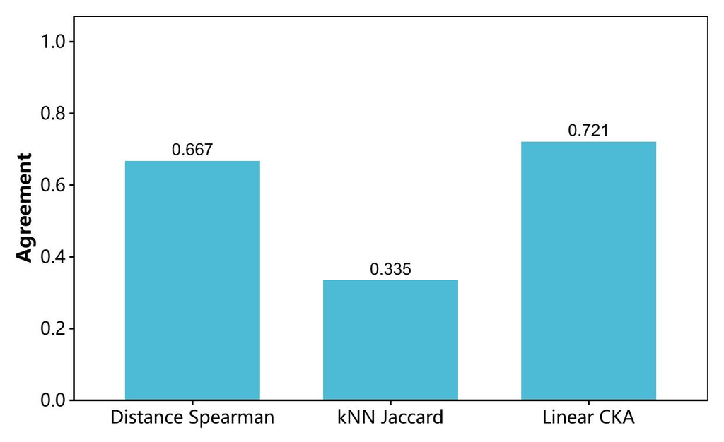

```r
knitr::include_graphics(fig1_jpg)
```

当前数据的几何结果显示，两种表示的 global alignment 为 CKA = 0.721，随机抽样距离排序相关为 0.667，局部邻居 Jaccard 为 0.335。这三项指标说明 cohort-model bank 实质性改写了 Direct 的全局与局部结构，且全局与局部的一致性差异并不相同。该差异是 CCS 产生新证据几何的必要条件，但不足以判断改写方向是否有益；还需结合技术边界减弱、新状态稳定性、跨癌种共享生物锚点与任务效用评价，癌种检索和 readout 不能单独给出结论。

## 5 外部癌种标签检索

```r
# ==== Figure 2: External retrieval cohort deltas (user-adjustable parameters) ====
fig2 <- list(
  # Larger height protects cohort labels from overlap; adjust with cohort count.
  width_in = 8.0,
  height_in = 8.5,
  base_size = 9,
  point_size = 2.2,
  zero_line_width = 0.55,
  legend_position = "bottom"
)
plot_retrieval <- retrieval_cohort_delta[
  retrieval_cohort_delta$sample_count >= params$min_cohort_n &
    retrieval_cohort_delta$metric %in%
      c("delta_top_k_label_rate", "delta_mrr"),
  ,
  drop = FALSE
]
plot_retrieval$metric <- factor(
  plot_retrieval$metric,
  levels = c("delta_top_k_label_rate", "delta_mrr"),
  labels = c("Top-k label rate", "Mean reciprocal rank")
)
cohort_order <- retrieval_delta_main$cohort[
  order(retrieval_delta_main$estimate)
]
plot_retrieval$cohort <- factor(plot_retrieval$cohort, levels = cohort_order)

p2 <- ggplot2::ggplot(
  plot_retrieval,
  ggplot2::aes(x = .data$estimate, y = .data$cohort, color = .data$metric)
) +
  ggplot2::geom_vline(
    xintercept = 0,
    linewidth = fig2$zero_line_width,
    color = "grey55"
  ) +
  ggplot2::geom_point(size = fig2$point_size) +
  ggplot2::scale_color_manual(
    values = unname(c(nature_colors[["red"]], nature_colors[["blue"]]))
  ) +
  ggplot2::labs(
    x = "Cohort-d1 minus Direct-GSClassifier",
    y = "External query cohort",
    color = "Metric"
  ) +
  theme_nature_readable(
    base_size = fig2$base_size,
    x_text_angle = 0,
    legend_position = fig2$legend_position
  )

# Readability check: cohort labels use a tall canvas, the zero line makes gain/loss
# direction explicit, and the bottom legend does not cover data.
fig2_jpg <- .ae_save_plot(
  p2, "figure-02-external-retrieval-cohort-delta", figure_dir,
  preview_dir, fig2, params$plot_preview_dpi
)
```

```
## Converting page 1 to E:/RCloud/RFactory/ccs/test/ablation-02/tmp/plot-previews/ablation-experiment-20260806203223/figure-02-external-retrieval-cohort-delta.jpg... done!
```

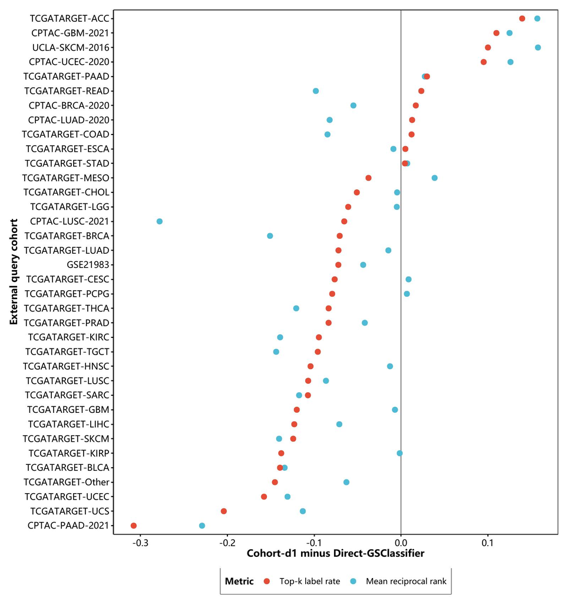

```r
knitr::include_graphics(fig2_jpg)
```

在 k = 30 时，当前数据结果显示 Cohort-d1 相对 Direct 的样本级 top-k 癌种一致率平均差为 **-0.079**，MRR 平均差为 -0.072。d1 的局部几何受传统癌种标签的主导较弱，这一结果本身不能说明生物效用下降。Top 3 正向 cohorts 依次是 TCGATARGET-ACC、CPTAC-GBM-2021 与 UCLA-SKCM-2016；癌种可恢复性下降最明显的是 **CPTAC-PAAD-2021**（-0.308）。**这种 cohort 间差异提示，cohort bank 对 lineage 信号的重加权具有异质性。** 后续需要检查这些 cohort 是否对应可复现的共享状态，不能仅凭癌种检索下降收紧 d1 的适用范围。

```r
# Purpose: Expose the strongest external retrieval gains and losses with sample counts.
# Input: Cohort-level paired top-k cancer-type agreement deltas.
# Parameters: Top/bottom count from params$interpret_top_n.
# Output: Interactive table of concrete cohorts and effect directions.
retrieval_extremes <- rbind(
  transform(utils::head(retrieval_top, params$interpret_top_n), direction = "gain"),
  transform(utils::head(retrieval_bottom, params$interpret_top_n), direction = "loss")
)
render_dt(
  retrieval_extremes[, c("direction", "cohort", "estimate", "sample_count")],
  pageLength = 2L * params$interpret_top_n
)
```

|  | direction | cohort | estimate | sample_count |
| --- | --- | --- | --- | --- |
| 1 | gain | TCGATARGET-ACC | 0.1393939393939394 | 77 |
| 2 | gain | CPTAC-GBM-2021 | 0.1097643097643098 | 99 |
| 3 | gain | UCLA-SKCM-2016 | 0.1 | 27 |
| 4 | loss | CPTAC-PAAD-2021 | -0.3078571428571429 | 140 |
| 5 | loss | TCGATARGET-UCS | -0.204093567251462 | 57 |
| 6 | loss | TCGATARGET-UCEC | -0.1578268876611418 | 181 |

该表给出了 lineage 重加权在具体 query cohort 中的表现：TCGATARGET-ACC 与 CPTAC-PAAD-2021 方向相反，cohort bank 对不同癌种的平滑程度并不相同。下一步可将这两组按 assay/source 分层，检验 d1 邻居在 pathway score、TME state 或其他非癌种锚点上是否更一致。若跨 cohort 状态一致性提高，且 Annoy/exact recall 继续高于 0.900，即可支持“有目的重构”，无须要求癌种 top-k 转为正向。

## 6 外部癌种线性 readout

```r
# ==== Figure 3: External linear readout cohort deltas (user-adjustable parameters) ====
fig3 <- list(
  width_in = 7.2,
  height_in = 7.5,
  base_size = 9,
  point_size = 2.4,
  zero_line_width = 0.55,
  legend_position = "none"
)
readout_plot <- readout_cohort[order(readout_cohort$delta_balanced_accuracy), ]
readout_plot$cohort <- factor(readout_plot$cohort, levels = readout_plot$cohort)
p3 <- ggplot2::ggplot(
  readout_plot,
  ggplot2::aes(x = .data$delta_balanced_accuracy, y = .data$cohort)
) +
  ggplot2::geom_vline(
    xintercept = 0,
    linewidth = fig3$zero_line_width,
    color = "grey55"
  ) +
  ggplot2::geom_point(
    size = fig3$point_size,
    color = nature_colors[["purple"]]
  ) +
  ggplot2::labs(
    x = "Balanced accuracy: Cohort-d1 minus Direct-GSClassifier",
    y = "External query cohort"
  ) +
  theme_nature_readable(
    base_size = fig3$base_size,
    x_text_angle = 0,
    legend_position = fig3$legend_position
  )

# Readability check: one metric avoids a redundant legend; a tall canvas keeps
# cohort names readable and the zero line exposes the sign of every paired effect.
fig3_jpg <- .ae_save_plot(
  p3, "figure-03-external-readout-cohort-delta", figure_dir,
  preview_dir, fig3, params$plot_preview_dpi
)
```

```
## Converting page 1 to E:/RCloud/RFactory/ccs/test/ablation-02/tmp/plot-previews/ablation-experiment-20260806203223/figure-03-external-readout-cohort-delta.jpg... done!
```

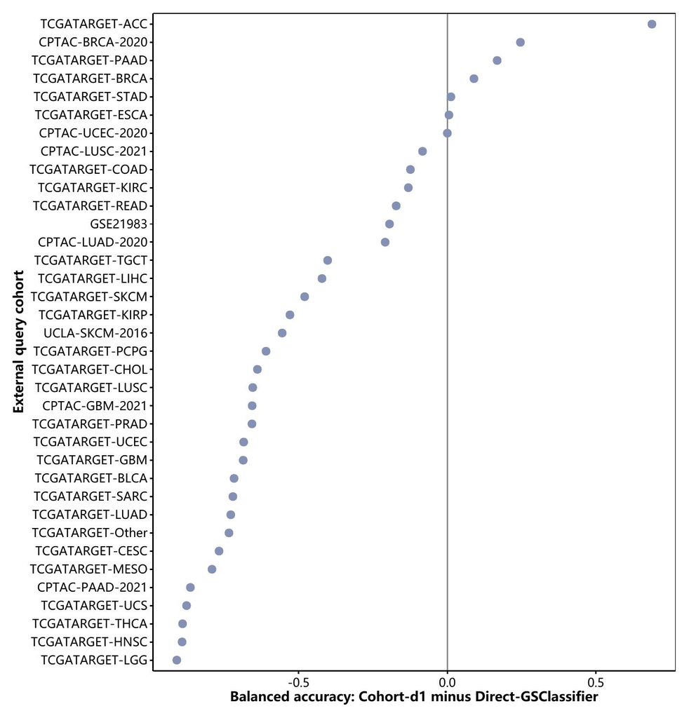

```r
knitr::include_graphics(fig3_jpg)
```

使用全部 reference cohorts 时，当前数据结果显示 Direct-GSClassifier 的外部 balanced accuracy 为 0.367，Cohort-d1 为 0.230，配对总体差为 **-0.137**，d1 明显低于 Direct。d1 的最佳 readout cohort 为 TCGATARGET-ACC（差 0.688），最差为 TCGATARGET-LGG（差 -0.910）。该比较使用 3-fold grouped CV，两种表示采用相同的预处理和调参预算。结果不支持“d1 让低复杂度模型更容易利用旧癌种标签”这一狭义主张；同一表示是否更容易读出 ICI response、pathway state 或新的 pan-cancer subtype，尚无法从本实验判断。

## 7 癌种 readout 的样本效率

```r
# ==== Figure 4: Paired learning curves (user-adjustable parameters) ====
fig4 <- list(
  width_in = 6.8,
  height_in = 4.4,
  base_size = 11,
  line_size = 0.9,
  point_size = 2.5,
  point_alpha = 0.9,
  legend_position = "bottom"
)
p4 <- ggplot2::ggplot(
  learning_summary,
  ggplot2::aes(
    x = .data$requested_fraction,
    y = .data$estimate,
    color = .data$representation,
    group = .data$representation
  )
) +
  ggplot2::geom_ribbon(
    ggplot2::aes(
      ymin = .data$estimate - 1.96 * .data$se,
      ymax = .data$estimate + 1.96 * .data$se,
      fill = .data$representation
    ),
    alpha = 0.14,
    color = NA
  ) +
  ggplot2::geom_line(linewidth = fig4$line_size) +
  ggplot2::geom_point(size = fig4$point_size, alpha = fig4$point_alpha) +
  ggplot2::scale_x_continuous(
    breaks = manifest$config$validation$learning_fractions,
    labels = scales::label_percent(accuracy = 1)
  ) +
  ggplot2::scale_color_manual(
    values = c(
      "Direct-GSClassifier" = nature_colors[["blue"]],
      "Cohort-d1" = nature_colors[["red"]]
    )
  ) +
  ggplot2::scale_fill_manual(
    values = c(
      "Direct-GSClassifier" = nature_colors[["blue"]],
      "Cohort-d1" = nature_colors[["red"]]
    )
  ) +
  ggplot2::labs(
    x = "Fraction of reference cohorts",
    y = "External balanced accuracy",
    color = "Representation",
    fill = "Representation"
  ) +
  theme_nature_readable(
    base_size = fig4$base_size,
    x_text_angle = 0,
    legend_position = fig4$legend_position
  )

# Readability check: four x ticks remain sparse, ribbons carry repeat uncertainty,
# and the external legend avoids covering either learning curve.
fig4_jpg <- .ae_save_plot(
  p4, "figure-04-paired-learning-curve", figure_dir,
  preview_dir, fig4, params$plot_preview_dpi
)
```

```
## Converting page 1 to E:/RCloud/RFactory/ccs/test/ablation-02/tmp/plot-previews/ablation-experiment-20260806203223/figure-04-paired-learning-curve.jpg... done!
```

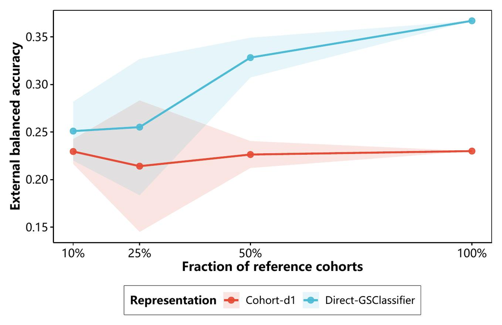

```r
knitr::include_graphics(fig4_jpg)
```

当前数据的学习曲线结果显示，在 10%、25%、50% 和 100% reference cohorts 下，d1-minus-Direct 的癌种 balanced-accuracy 差依次为 -0.021, -0.041, -0.102, -0.137。阴影给出 3 次配对重复的近似 95% CI（均值 ± 1.96 SE）。训练比例增加后，负向差值仍未消失，表明 d1 对旧癌种标签的去强化并非仅由小样本估计造成。每个比例的两种表示共享 cohort subset hash 与外部 query hash，可排除训练组成或测试样本漂移对曲线差的影响。该曲线仅评价 cancer-type readout 的样本效率，不能据此认定 d1 对所有新分型任务都存在“过度压缩”。

## 8 技术来源与癌种锚点的联合评估

```r
# ==== Figure 5: Technical-neighbor excess deltas (user-adjustable parameters) ====
fig5 <- list(
  width_in = 6.8,
  height_in = 4.2,
  base_size = 10,
  point_size = 1.8,
  point_alpha = 0.72,
  zero_line_width = 0.55,
  legend_position = "none"
)
p5 <- ggplot2::ggplot(
  technical_delta,
  ggplot2::aes(
    x = .data$technical_factor,
    y = .data$estimate,
    color = .data$technical_factor
  )
) +
  ggplot2::geom_hline(
    yintercept = 0,
    linewidth = fig5$zero_line_width,
    color = "grey55"
  ) +
  ggplot2::geom_boxplot(outlier.shape = NA, width = 0.5, alpha = 0.2) +
  ggplot2::geom_jitter(
    width = 0.12,
    size = fig5$point_size,
    alpha = fig5$point_alpha
  ) +
  ggplot2::scale_color_manual(
    values = unname(nature_colors[seq_along(technical_columns)])
  ) +
  ggplot2::labs(
    x = "Technical factor",
    y = "Delta in same-technology excess",
    color = "Technical factor"
  ) +
  theme_nature_readable(
    base_size = fig5$base_size,
    x_text_angle = 0,
    legend_position = fig5$legend_position
  )

# Readability check: factor labels are short, jitter exposes cohort heterogeneity,
# and a horizontal zero line separates reduced from increased technical clustering;
# the redundant color legend is removed because the x-axis already names each factor.
fig5_jpg <- .ae_save_plot(
  p5, "figure-05-technical-neighbor-excess", figure_dir,
  preview_dir, fig5, params$plot_preview_dpi
)
```

```
## Converting page 1 to E:/RCloud/RFactory/ccs/test/ablation-02/tmp/plot-previews/ablation-experiment-20260806203223/figure-05-technical-neighbor-excess.jpg... done!
```

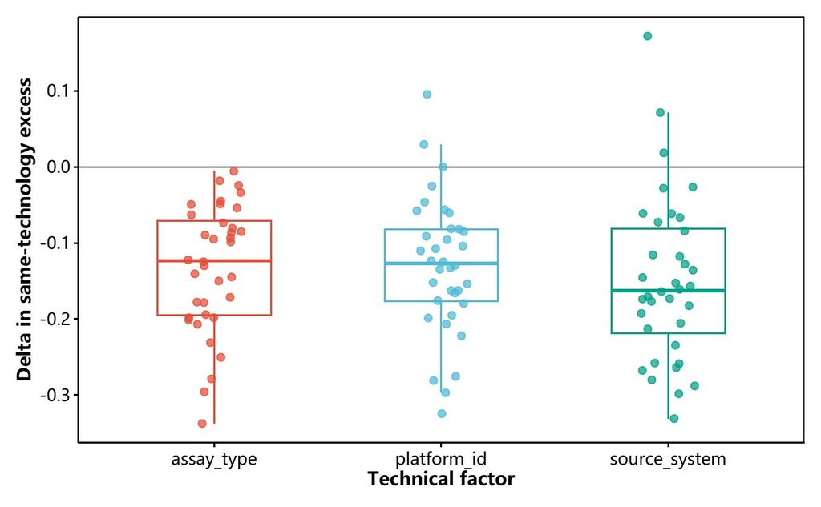

```r
knitr::include_graphics(fig5_jpg)
```

当前数据结果显示，在同一 cancer_type 的 reference 背景内校正后，assay_type = -0.133; platform_id = -0.130; source_system = -0.150。负值表示 d1 减少了超出癌种构成所能解释的同技术邻居聚集，正值表示技术来源更集中。三个技术因子的均值均下降，是本轮支持 cohort-conditioned integration 最直接的正向结果。癌种一致率也从 0.437 降到 0.358，表明这种混合伴随去癌种中心化。由于 `cancer_type` 只是粗粒度锚点，现有数据还无法区分“保留共享肿瘤状态的有目的融合”与“无选择混合”。技术 excess 下降可作为机制线索，但不足以断言 batch removal 已成功或生物信号已被抹平。

## 9 module 贡献集中度

```r
# ==== Figure 6: d1 module variance concentration (user-adjustable parameters) ====
fig6 <- list(
  width_in = 7.2,
  height_in = 5.8,
  base_size = 9,
  bar_width = 0.72,
  legend_position = "none"
)
module_top$module_label <- .ae_resolve_module_labels(
  module_top$module_id,
  data_profile$resolution_audit
)
module_top$module_label <- factor(
  module_top$module_label,
  levels = rev(module_top$module_label)
)
p6 <- ggplot2::ggplot(
  module_top,
  ggplot2::aes(x = .data$variance_share, y = .data$module_label)
) +
  ggplot2::geom_col(
    width = fig6$bar_width,
    fill = nature_colors[["green"]]
  ) +
  ggplot2::scale_x_continuous(labels = scales::label_percent(accuracy = 0.1)) +
  ggplot2::labs(x = "Share of module-level variance", y = "Frozen cohort module") +
  theme_nature_readable(
    base_size = fig6$base_size,
    x_text_angle = 0,
    legend_position = fig6$legend_position
  )

# Readability check: only the top 20 modules are labeled, horizontal bars protect
# tissue|cohort names from clipping, and the vector PDF preserves small text.
fig6_jpg <- .ae_save_plot(
  p6, "figure-06-module-variance-concentration", figure_dir,
  preview_dir, fig6, params$plot_preview_dpi
)
```

```
## Converting page 1 to E:/RCloud/RFactory/ccs/test/ablation-02/tmp/plot-previews/ablation-experiment-20260806203223/figure-06-module-variance-concentration.jpg... done!
```

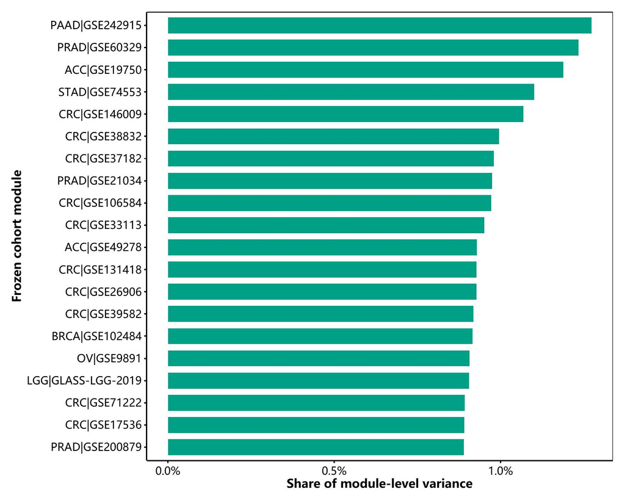

```r
knitr::include_graphics(fig6_jpg)
```

当前数据的 module 结果显示，方差贡献最高的 module 为 PAAD|GSE242915（1.3%），前 10 个 modules 合计 10.7%。图中的历史 `Undefined|cohort` 仅在显示层替换为已核验真实 tissue，底层 module ID、模型路径与审计哈希不变。d1 block 宽度为 3–4，距离计算已按 block 宽度和 module 数等权，因此这种集中度来自概率输出分布，并非“列更多自动权重更大”。**这种贡献差异提示，如果 retrieval/readout 收益也集中于同一批 modules，cohort congress 应表述为少数高贡献 bank 成员的作用，不能归为全部 modules 的均匀集体效应。**

## 10 输入信息压缩与可恢复性

```r
# ==== Figure 7: Feature-type reconstruction metrics (user-adjustable parameters) ====
fig7 <- list(
  width_in = 7.0,
  height_in = 4.2,
  base_size = 10,
  bar_width = 0.68,
  legend_position = "bottom"
)
decoder_plot <- rbind(
  data.frame(
    feature_type = "gene_pair",
    metric = c("Balanced accuracy", "1 - Brier"),
    value = c(
      decoder_summary$balanced_accuracy[decoder_summary$feature_type == "gene_pair"],
      1 - decoder_summary$brier[decoder_summary$feature_type == "gene_pair"]
    )
  ),
  data.frame(
    feature_type = "single_bin",
    metric = c("Spearman", "1 - scaled MAE"),
    value = c(
      decoder_summary$spearman[decoder_summary$feature_type == "single_bin"],
      1 / (1 + decoder_summary$mae[decoder_summary$feature_type == "single_bin"])
    )
  ),
  data.frame(
    feature_type = "set_pair",
    metric = c("Spearman", "1 - scaled RMSE"),
    value = c(
      decoder_summary$spearman[decoder_summary$feature_type == "set_pair"],
      1 / (1 + decoder_summary$rmse[decoder_summary$feature_type == "set_pair"])
    )
  )
)
p7 <- ggplot2::ggplot(
  decoder_plot,
  ggplot2::aes(x = .data$feature_type, y = .data$value, fill = .data$metric)
) +
  ggplot2::geom_col(
    position = "dodge",
    width = fig7$bar_width
  ) +
  ggplot2::scale_fill_manual(values = unname(nature_colors[seq_len(6L)])) +
  ggplot2::scale_y_continuous(limits = c(0, 1.02), breaks = seq(0, 1, 0.2)) +
  ggplot2::labs(
    x = "Direct feature type",
    y = "Reconstruction score",
    fill = "Metric"
  ) +
  theme_nature_readable(
    base_size = fig7$base_size,
    x_text_angle = 0,
    legend_position = fig7$legend_position
  )

# Readability check: six color-blind-safe bars are separated by feature type;
# the legend is external and no heterogeneous raw loss is merged into one winner score.
fig7_jpg <- .ae_save_plot(
  p7, "figure-07-feature-type-reconstruction", figure_dir,
  preview_dir, fig7, params$plot_preview_dpi
)
```

```
## Converting page 1 to E:/RCloud/RFactory/ccs/test/ablation-02/tmp/plot-previews/ablation-experiment-20260806203223/figure-07-feature-type-reconstruction.jpg... done!
```

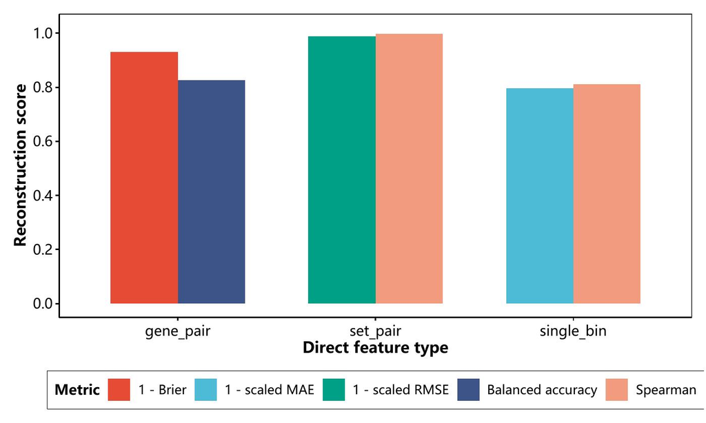

```r
knitr::include_graphics(fig7_jpg)
```

从外部 query 重建完整 Direct 输入时，gene-pair balanced accuracy 为 0.826、Brier 为 0.069；single-bin 的 Spearman/MAE 为 0.811 / 0.255；唯一 set-pair 的 Spearman/RMSE 为 0.998 / 0.012。这些数值说明 d1 是有损且有方向的重表达，无法作为 Direct feature 的可逆容器。这一信息瓶颈符合 CCS 从低输入 feature 构建队列证据并产生新状态的设计。其代价取决于被压缩的是队列/癌种捷径，还是新状态与下游任务所需信息。后续需要将 decoder 最差的 gene-pairs 和 single-bins 对齐 pathway、TME 与 outcome 锚点，不能只检查它们是否集中于癌种 readout 最差的 cohorts。

Null-Perm 的资格状态为 **not_eligible**。36 个 query cohorts 的 cancer_type 在各 cohort 内恒定，样本内置换无法检验该锚点，因此没有生成形式完整却无检验力的伪对照。三组 Null-RP 在 k = 30 的癌种一致率范围为 0.403–0.413，均高于 d1 的 0.358。该结果不支持“任意投影都会同等程度去癌种中心化”，d1 的 lineage 重写与 cohort-model bank 的特定映射有关。Null-RP 仅说明 d1 不利于恢复癌种；cohort bank 对新状态发现是否必要，仍需使用与目标一致的 Null 对照和状态/任务指标判断。

## 11 讨论与分析

本次结果显示，d1 对旧癌种标签的 top-k/MRR 平均 retrieval 差为 -0.079，低于 Direct；总体癌种 readout 差为 -0.137，方向同样为负。全训练比例的癌种学习曲线差为 -0.137，增加训练数据未能消除差距。对于恢复旧癌种标签这一任务，Direct-GSClassifier 是更简单、效果更好的表示。CCS 则希望用多队列证据重表达同一份低输入 feature，发现不必等同于传统癌种的 pan-cancer states。在这一目标下，癌种可恢复性下降可能是去中心化的预期表现，不能直接视为负面结局。

当前数据结果显示，三个技术来源 excess 同向下降：assay_type = -0.133; platform_id = -0.130; source_system = -0.150，这是本次最强的正向结果。`d1` 的 CKA、距离相关和局部 Jaccard 也显示 cohort bank 对原表示进行了非平凡重表达。综合来看，**`d1` 伴随去癌种中心化和技术边界减弱，但本轮实验尚未测量新状态的有用性。** 这既不能证明 CCS 已经成功，也不能让与研究目标不等价的癌种分类决定整体结论。

当前数据中，reference/query 分别为 24487 / 10103 个样本，这一不对称规模构成本报告的第一项不确定性。reference `d1` 被保守标记为 `in_sample`，本报告确认的是 filtered query 对冻结 bank 的外部泛化，不将 reference 内部几何视为无泄漏性能。Excel cancer_type 虽未用于冻结 bank 训练，但部分癌种与 cohort/assay 高度绑定；技术 excess 的背景校正只能缓解这一混杂，不能将其完全消除。本轮唯一的独立生物锚点是 cancer_type，未纳入 pathway/TME state、独立分子表型、outcome 或 `d2`/`d3`/metaCCS 稳定性，尚不能判断去癌种中心化后得到的是有用新结构还是无选择混合。项目负责人也没有预先指定与新状态目标一致的最小重要差异，因此本报告不以零差异或任意事后阈值判定 `d1`“胜出”或“失败”。

后续分析可沿三条路径推进。在冻结 `d1` 上加入独立于癌种标签的 pathway score、TME state 或多组学表型，并用 leave-one-cohort-out 检验共享状态可读性；若 `d1` 在技术 excess 不升高的同时提高这些锚点的外部一致性，即可支持有目的重表达。进入 `d2`/`d3`/metaCCS 层后，可评估跨 seed/重采样的 cluster Jaccard、ARI、状态 split/merge 和 lineage-conditioned biology；共享状态能够重现，并在具体 lineage 内保留可解释的差异实现，才支持“虚拟元肿瘤—新亚型”。还需对从小规模到完整 bank 的多档冻结 modules 构建嵌套 scaling 曲线，同时报告状态重现性、外部锚点效用、module 边际增益与 effective rank；只有增加队列后出现非冗余且可重复的收益，才能支持“少量 feature 可随 cohort evidence scaling”。

## 12 数字准确性验证

| 数字描述 | 来源变量/计算 | 结果位置 |
| --- | --- | --- |
| reference/query 样本与 cohort 数 | `manifest$reference_*` / `manifest$query_*` | `manifest.rds` |
| CKA、距离相关、kNN Jaccard | `native_geometry$metrics` | `native_geometry.rds` |
| top-k/MRR 差与最差 cohort | `retrieval$paired` → `.ae_retrieval_cohort_delta()` | `retrieval.rds` |
| readout balanced accuracy | `readout$overall` / `readout$paired_by_cohort` | `readout.rds` |
| 学习曲线与 cohort subset hash | `learning_curve$metrics` / `$paired` | `learning_curve.rds` |
| decoder 指标 | `tradeoffs$decoder$summary` | `tradeoffs.rds` |
| Annoy exact recall | `retrieval$search_validation` | `retrieval.rds` |

所有核心数值均由上述对象动态嵌入。两种表示的主差值统一定义为 Cohort-d1 减 Direct-GSClassifier；学习曲线中的 test sample hash 和 cohort subset hash 成对一致；图表展示均使用正式 PDF 转换的 JPG，没有另行渲染一套结果。

### 12.1 自检报告

| 检查项 | 状态 | 证据 |
| --- | --- | --- |
| 混合架构 | ✅ | `.R` 负责全量计算，`.Rmd` 只做展示阈值与解读 |
| 外部 provenance | ✅ | 10103 个 query 均来自 filtered cohorts |
| Direct 合同 | ✅ | 529 = 32 single-bin + 496 gene-pair + 1 set-pair |
| query/reference 隔离 | ✅ | 邻居表逐行满足 query cohort ≠ reference cohort |
| 近似搜索门禁 | ✅ | Direct/d1 recall = 0.979 / 0.986 |
| 配对学习曲线 | ✅ | 两表示共享 cohort subset/test hashes，lambda 预算一致 |
| Null-Perm 资格 | ✅ | 恒定 cohort 内锚点标记为 not_eligible |
| tissue 恢复 | ✅ | 45 个 cohort / 8626 个样本完成映射，剩余 Undefined = 0 |
| 图表质量 | ✅ | 3 张数据审计图 + 7 张消融结果图均交付矢量 PDF 与 PDF 派生 JPG，英文轴、外置图例、色盲友好配色 |
| 结果解读 | ✅ | 每个图表附近均绑定当前 cohort/指标/数值与可证伪后续 |
| 数字可追溯 | ✅ | 内联数值来自 8 个正式 RDS 对象及其明确计算链 |